# Прогнозирование заказов такси

## Постановка цели

Заказчик (компания такси) собрала исторические данные о заказах такси в аэропортах. Чтобы привлекать больше водителей в период пиковой нагрузки, нужно спрогнозировать количество заказов такси на следующий час. Постройте модель для такого предсказания.

Значение метрики *RMSE* на тестовой выборке должно быть не больше 48.

Перечень задач для осуществления поставленной цели:

1. Загрузить данные и выполнить их ресемплирование по одному часу.
2. Проанализировать данные.
3. Обучить разные модели с различными гиперпараметрами. Тестовая выборка - 10% от исходных данных.
4. Проверить данные на тестовой выборке и сделать выводы.

Данные лежат в файле `taxi.csv`. Количество заказов находится в столбце `num_orders`.

## 1 Подготовка

```python
import pandas as pd
import numpy as np
import matplotlib.pyplot as plt
import statsmodels.api as sm
from sklearn.model_selection import train_test_split

from sklearn.preprocessing import StandardScaler
from sklearn.linear_model import LinearRegression
from sklearn.ensemble import RandomForestRegressor
from sklearn.linear_model import Lasso
import lightgbm as lgb
from sklearn.metrics import mean_squared_error
from sklearn.model_selection import TimeSeriesSplit

from sklearn.model_selection import GridSearchCV
from sklearn.pipeline import make_pipeline
```

```python
taxi_data = pd.read_csv('taxi.csv')
```

```python
taxi_data.head()
```

|  | datetime | num_orders |
| --- | --- | --- |
| 0 | 2018-03-01 00:00:00 | 9 |
| 1 | 2018-03-01 00:10:00 | 14 |
| 2 | 2018-03-01 00:20:00 | 28 |
| 3 | 2018-03-01 00:30:00 | 20 |
| 4 | 2018-03-01 00:40:00 | 32 |

```python
taxi_data.info()
```

```
<class 'pandas.core.frame.DataFrame'>
RangeIndex: 26496 entries, 0 to 26495
Data columns (total 2 columns):
 #   Column      Non-Null Count  Dtype
---  ------      --------------  -----
 0   datetime    26496 non-null  object
 1   num_orders  26496 non-null  int64
dtypes: int64(1), object(1)
memory usage: 414.1+ KB
```

```python
taxi_data['datetime'] = pd.to_datetime(taxi_data['datetime'])
taxi_data.set_index('datetime', inplace=True)
taxi_data = taxi_data.resample('H').sum()
```

```python
taxi_data.index.is_monotonic
```

```
True
```

Данные загружены, индекс в виде даты выставлен, ресемплирование по одному часу сделано.

## 2 Анализ

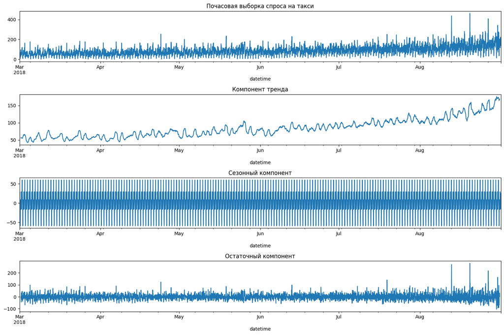

```python
decomposition = sm.tsa.seasonal_decompose(taxi_data['num_orders'], period=24)

fig, ax = plt.subplots(nrows=4, ncols=1, figsize=(15,10))

taxi_data['num_orders'].plot(ax=ax[0])
ax[0].set_title('Почасовая выборка спроса на такси')

decomposition.trend.plot(ax=ax[1])
ax[1].set_title('Компонент тренда')

decomposition.seasonal.plot(ax=ax[2])
ax[2].set_title('Сезонный компонент')

decomposition.resid.plot(ax=ax[3])
ax[3].set_title('Остаточный компонент')

plt.tight_layout()
plt.show()
```

Как видно из графика, в выбранных данных имеется тренд – спрос на такси в течение всего времени постпенно увеличвается. Также показана обычная суточная для такси сезонность – днём заказов больше, а ночью их меньше. Остаточный компонент показывает некие аномальные скачки в течение августа

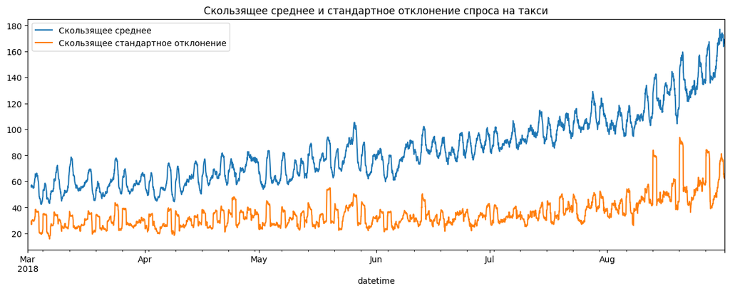

```python
plt.figure(figsize=(15,5))
taxi_data['num_orders'].rolling(window=24).mean().plot(label='Скользящее среднее')
taxi_data['num_orders'].rolling(window=24).std().plot(label='Скользящее стандартное отклонение')
plt.legend()
plt.title('Скользящее среднее и стандартное отклонение спроса на такси')
plt.show()
```

Скользящее среднее указывает на тренд, который мы увидели в предыдущем графике. А вот увеличивающееся скользящее стандартное отклонение указывет на то, что спрос становится более изменчивым.

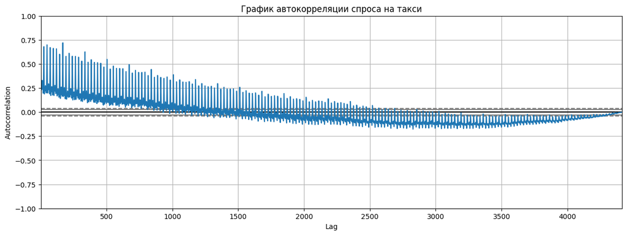

```python
plt.figure(figsize=(15,5))
pd.plotting.autocorrelation_plot(taxi_data['num_orders'])
plt.title('График автокорреляции спроса на такси')
plt.show()
```

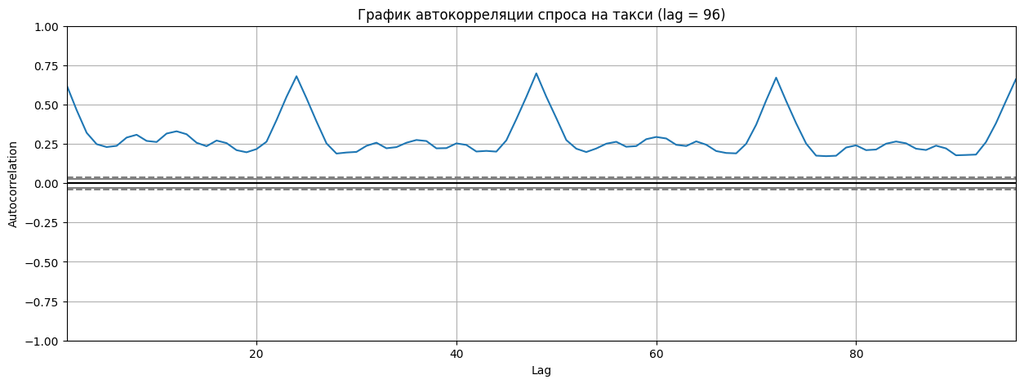

```python
plt.figure(figsize=(15,5))
pd.plotting.autocorrelation_plot(taxi_data['num_orders']).set_xlim([1, 96])
plt.title('График автокорреляции спроса на такси (lag = 96)')
plt.show()
```

Мы видим значительный всплеск на графике автокорреляции при лаговых значениях кратных 24-ём, что снова говорит нам о ежесуточной сезонности.

## 3 Обучение

### 3.1 Подготовка

```python
def make_features(data, max_lag, rolling_mean_size):
    data = data.drop(columns=data.columns.difference(['num_orders']))
    for lag in range(1, max_lag + 1):
        data[f"lag_{lag}"] = data['num_orders'].shift(lag)

    data['rolling_mean'] = data['num_orders'].shift().rolling(rolling_mean_size).mean()
    data['rolling_std'] = data['num_orders'].shift().rolling(rolling_mean_size).std()

    return data
```

```python
taxi_data = make_features(taxi_data, 24, 24)
```

Написали функцию для создания дополнительных фичей, которые помогут достигнуть более точного предсказания.

```python
train_data, test_data = train_test_split(taxi_data, test_size=0.1, shuffle=False)
train_data = train_data.dropna()
print('Training data shape:', train_data.shape)
print('Test data shape:', test_data.shape)
```

```
Training data shape: (3950, 27)
Test data shape: (442, 27)
```

```python
train_features = train_data.drop('num_orders', axis=1)
train_target = train_data['num_orders']
test_features = test_data.drop('num_orders', axis=1)
test_target = test_data['num_orders']
```

Разделили выборки, всё готово к обучению.

### 3.2 Лес

```python
def train_random_forest_model(X_train, y_train, n_estimators, max_depth, min_samples_leaf):

    model = RandomForestRegressor(random_state=222)

    param_grid = {
        'n_estimators': n_estimators,
        'max_depth': max_depth,
        'min_samples_leaf': min_samples_leaf
    }

    tscv = TimeSeriesSplit(n_splits=5)

    search = GridSearchCV(
        model,
        param_grid,
        scoring='neg_root_mean_squared_error',
        cv=tscv,
        n_jobs=-1
    )


    search.fit(X_train, y_train)

    return search.best_estimator_, -search.best_score_
```

```python
%%time
hyperparam_forest, RMSE_forest = train_random_forest_model(train_features,
                                                           train_target,
                                                           np.arange(1, 201, 25),
                                                           np.arange(1, 11),
                                                           np.arange(1, 5))
print(f"Лучшие гиперпараметры для леса: {hyperparam_forest}")
print(f"Лучший RMSE леса: {RMSE_forest}")
```

```
Лучшие гиперпараметры для леса: RandomForestRegressor(max_depth=10, min_samples_leaf=3, n_estimators=101,
                      random_state=222)
Лучший RMSE леса: 26.008173511748076
CPU times: total: 6.84 s
Wall time: 1min 18s
```

### 3.3 Линейная регрессия

```python
def train_linear_regression_model(X_train, y_train):
    model = make_pipeline(StandardScaler(), LinearRegression())

    tscv = TimeSeriesSplit(n_splits=5)

    search = GridSearchCV(
        model,
        param_grid={},
        scoring='neg_root_mean_squared_error',
        cv=tscv,
        n_jobs=-1
    )

    search.fit(X_train, y_train)

    return -search.best_score_
```

```python
%%time
RMSE_lin = train_linear_regression_model(train_features, train_target)
print(f"Лучший RMSE линейной регрессии: {RMSE_lin}")
```

```
Лучший RMSE линейной регрессии: 27.184078019456205
CPU times: total: 31.2 ms
Wall time: 21 ms
```

### 3.4 LightGBM

```python
def train_lgbm(X_train, y_train, num_leaves, n_estimators):
    params = {
        'objective': ['regression'],
        'metric': ['rmse'],
        'num_leaves': num_leaves,
        'n_estimators': n_estimators
    }

    tscv = TimeSeriesSplit(n_splits=5)

    model = lgb.LGBMRegressor(random_state=222)

    search = GridSearchCV(
        model,
        params,
        scoring='neg_root_mean_squared_error',
        cv=tscv,
        n_jobs=-1
    )

    search.fit(X_train, y_train)

    return search.best_estimator_, -search.best_score_
```

```python
%%time
hyperparam_lgbm, RMSE_lgbm = train_lgbm(train_features,
                                        train_target,
                                        np.arange(2, 43, 10),
                                        np.arange(0, 201, 25))
print(f"Лучшие гиперпараметры для LightGBM: {hyperparam_lgbm}")
print(f"Лучший RMSE для LightGBM: {RMSE_lgbm}")
```

```
Лучшие гиперпараметры для LightGBM: LGBMRegressor(metric='rmse', n_estimators=75, num_leaves=32,
              objective='regression', random_state=222)
Лучший RMSE для LightGBM: 25.633885190809828
CPU times: total: 2.45 s
Wall time: 1.59 s
```

### 3.5 Лассо

```python
def train_lasso(X_train, y_train, alpha, max_iter):
    params = {
        'lasso__alpha': alpha,
        'lasso__max_iter': max_iter
    }

    tscv = TimeSeriesSplit(n_splits=5)

    model = make_pipeline(StandardScaler(), Lasso(random_state=222))

    search = GridSearchCV(
        model,
        params,
        scoring='neg_root_mean_squared_error',
        cv=tscv,
        n_jobs=-1
    )

    search.fit(X_train, y_train)

    return search.best_estimator_, -search.best_score_
```

```python
%%time
hyperparam_lasso, RMSE_lasso = train_lasso(train_features,
                                        train_target,
                                        np.arange(0.001, 1.1, 0.1),
                                        np.arange(500, 5001, 500))
print(f"Лучшие гиперпараметры для Lasso: {hyperparam_lasso}")
print(f"Лучший RMSE для Lasso: {RMSE_lasso}")
```

```
Лучшие гиперпараметры для Lasso: Pipeline(steps=[('standardscaler', StandardScaler()),
                ('lasso',
                 Lasso(alpha=0.30100000000000005, max_iter=500,
                       random_state=222))])
Лучший RMSE для Lasso: 27.102416892672146
CPU times: total: 2.69 s
Wall time: 572 ms
```

Самой точной (хоть и не самой быстрой) оказалась модель градиентного бустинга (RMSE = 25.63). Приступим к тестированию.

## 4 Тестирование

```python
def test_lgbm(X_train, y_train, X_test, y_test, num_leaves, n_estimators):
    model = lgb.LGBMRegressor(random_state=222, num_leaves=num_leaves, n_estimators=n_estimators)

    model.fit(X_train, y_train)

    predictions = model.predict(X_test)

    rmse_value = mean_squared_error(y_test, predictions) ** 0.5

    return rmse_value, predictions
```

```python
rmse_test_lgbm, test_predictions = test_lgbm(train_features, train_target, test_features, test_target, 32, 75)
print(f"RMSE LightGBM модели (тестовая выборка) равен: {rmse_test_lgbm}")
```

```
RMSE LightGBM модели (тестовая выборка) равен: 42.99458126123183
```

RMSE = 42.99, а значит цель достигнута.

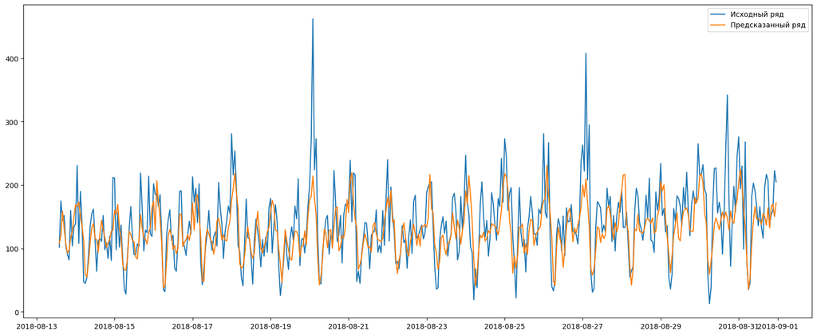

```python
data_graph = pd.DataFrame({'original': test_target, 'predicted': test_predictions})

fig = plt.figure(figsize=(20, 8))
plt.plot(data_graph['original'], label='Исходный ряд')
plt.plot(data_graph['predicted'], label='Предсказанный ряд')
plt.legend()
plt.show()
```

## Итог

Для компании заказа такси была разработана модель прогнозирования количества заказов такси на следующий час на основе исторических данных о заказах в аэропортах. Для этого были выполнены следующие шаги:

Были загружены исходные данные о заказах такси в аэропортах и выполнено их ресемплирование по одному часу.

Был проведен анализ данных, который показал сезонность и тренд в данных.

Были обучены различные модели с различными гиперпараметрами, включая линейную регрессию, случайный лес, градиентный бустинг и лассо.

Самой успешной моделью в палне точности была выбрана модель градиентного бустинга LightGBM, после чего была проведена проверка данных на тестовой выборке, которая составляла 10% от исходных данных. Значение метрики RMSE на тестовой выборке составило 42.99, что удовлетворяет требованию поставленной задачи (не больше 48).

Итак, нами была успешно разработана модель прогнозирования количества заказов такси на следующий час на основе исторических данных о заказах в аэропортах. Эта модель позволит компании более эффективно привлекать водителей в период пиковой нагрузки и улучшить качество обслуживания своих клиентов.